# Viral CAI Analysis

Rae G

December 19, 2017

## What am I trying to do?

In this R markdown I will explore the relationships between viruses and their codon adaptability to Human. All viruses studied infect humans, they will be somewhat categorized by their genome type and host range, but mostly by various traits of the transcripts encoded in their genomes such as length, GC content, Codon adaptability, longest stretch of non-optimal codons, and percent human optimal codon content.

## How do I intend to do it?

I will use descriptive statistics and linear models to visually show relationships.

virus_tidy was created by the get_data function from “Determining human codon optimality of several human viruses”

```r
virus_tidy <- readRDS("virus_tidy.txt")
```

### what does this data look like on the human genome

For comparison and to set a baseline for downstream analyses it is important to know how well an average human transcript is “adapted” to human codon usage.

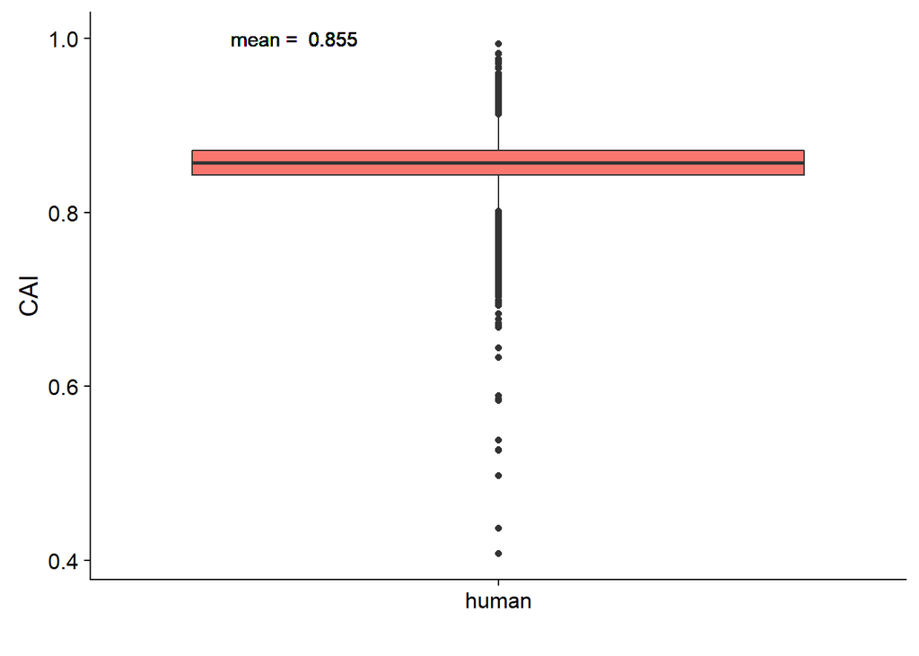

```r
HScDNA_tidy <- readRDS("HScDNA_longest_tidy.txt")

human_CAI <- mean(HScDNA_tidy$CAI)
human_percent_opt <- mean(HScDNA_tidy$percent_opt)

HScDNA_tidy %>% ggplot(aes(human, CAI, fill = human)) +
                      geom_boxplot() +
                      xlab("") +
                      geom_text(aes(x = 0.75, y = 1, label = paste("mean = ", format(human_CAI, digits = 3)))) +
                      theme(legend.position="none")
```

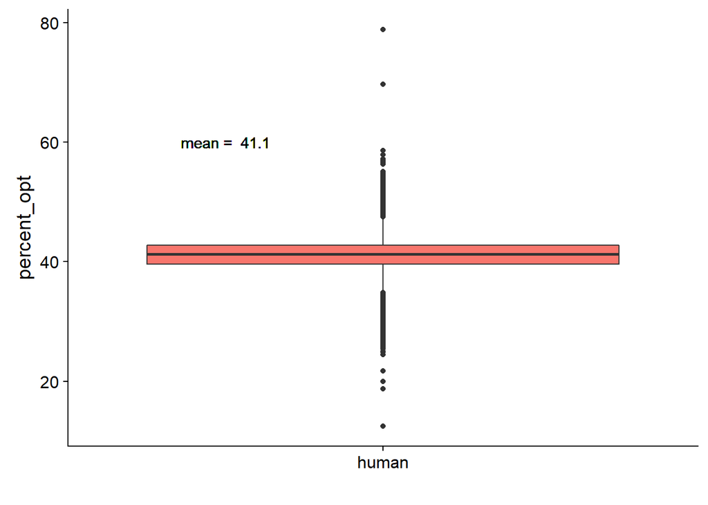

```r
HScDNA_tidy %>% ggplot(aes(human, percent_opt, fill = human)) +
                      geom_boxplot() + xlab("") +
                      geom_text(aes(x = 0.75, y = 60, label = paste("mean = ", format(human_percent_opt, digits = 3)))) +
                      theme(legend.position="none")
```

An average human transcript has a CAI of 0.8554489 and percent_opt of 41.1164426%

### Quick Descriptions of Collected Data

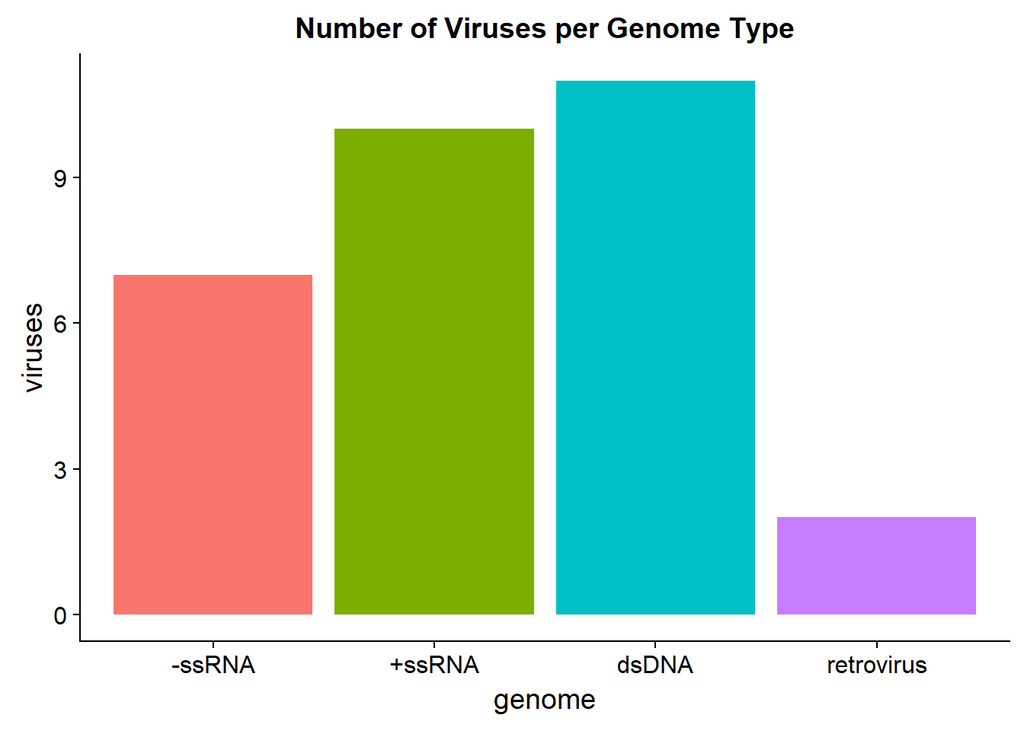

```r
virus_tidy %>% group_by(genome) %>%
               summarize(viruses = length(unique(virus))) %>%
               ggplot(aes(genome, viruses, fill = genome)) +
                      geom_bar(stat = "identity") +
                      labs(xlab = "Genome Type",
                           ylab = "Number of Viruses",
                           title = "Number of Viruses per Genome Type") +
                      theme(legend.position = "none")
```

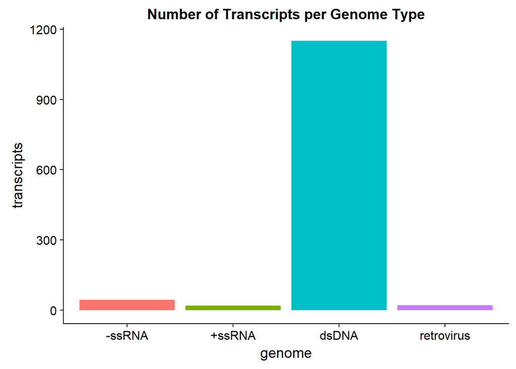

```r
virus_tidy %>% group_by(genome) %>%
               summarize(transcripts = n()) %>%
               ggplot(aes(genome, transcripts, fill = genome)) +
                      geom_bar(stat = "identity") +
                      labs(xlab = "Genome Type",
                           ylab = "Number of Transcripts",
                           title = "Number of Transcripts per Genome Type") +
               theme(legend.position="none")
```

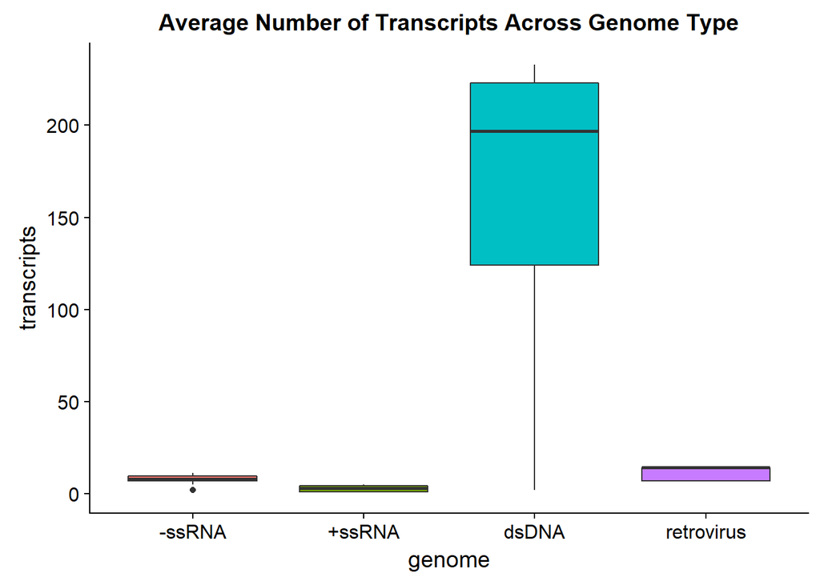

```r
virus_tidy %>% group_by(virus) %>%
               mutate(transcripts = n()) %>%
               ggplot(aes(genome, transcripts, fill = genome)) +
                      geom_boxplot() +
                      labs(xlab = "Genome Type",
                           ylab = "Average Number of Transcripts",
                           title = "Average Number of Transcripts Across Genome Type") +
               theme(legend.position="none")
```

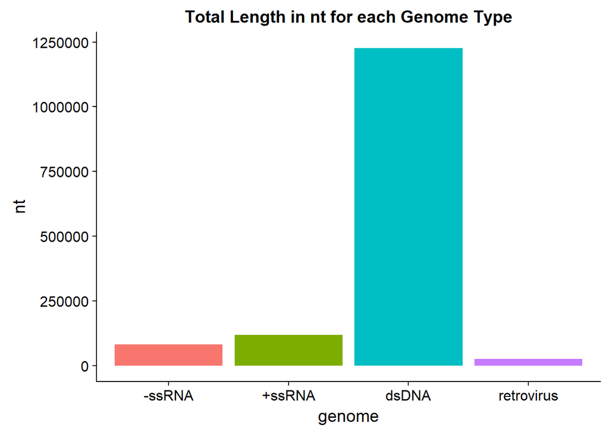

```r
virus_tidy %>% group_by(genome) %>%
               summarize(nt = sum(length)) %>%
               ggplot(aes(genome, nt, fill = genome)) +
                      geom_bar(stat = "identity") +
                      labs(xlab = "Genome Type",
                           ylab = "Total length (nt)",
                           title = "Total Length in nt for each Genome Type") +
                      theme(legend.position="none")
```

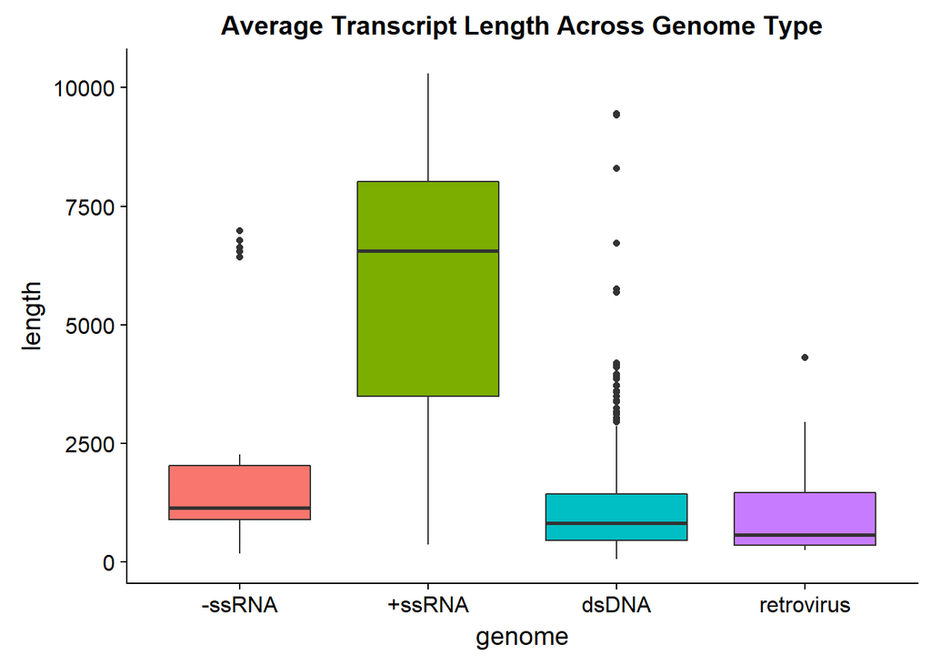

```r
virus_tidy %>% group_by(virus) %>%
               ggplot(aes(genome, length, fill = genome)) +
               geom_boxplot() +
               labs(xlab = "Genome Type",
                    ylab = "Average Transcript Length (nt)",
                    title = "Average Transcript Length Across Genome Type") +
               theme(legend.position="none")
```

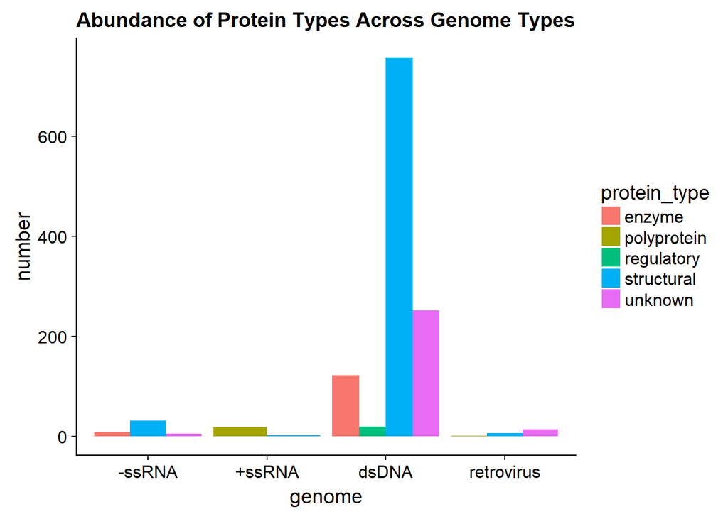

```r
virus_tidy %>% group_by(genome, protein_type) %>%
               summarize(number = n()) %>%
               ggplot(aes(genome, number, fill = protein_type)) +
               geom_bar(stat = "identity", position = "dodge") +
               labs(xlab = "Genome Type",
                    ylab = "Number of Protein Type",
                    title = "Abundance of Protein Types Across Genome Types")
```

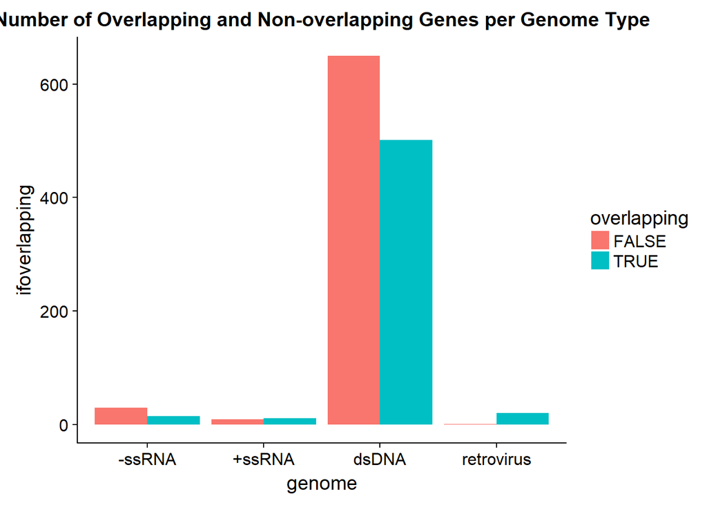

```r
virus_tidy %>% mutate(overlapping = ifelse(grepl("NA", virus_tidy$overlap, fixed = TRUE), "FALSE", "TRUE")) %>%
               group_by(genome, overlapping, fill = overlapping) %>% summarise(ifoverlapping = n()) %>%
               ggplot(aes(genome, ifoverlapping, fill = overlapping)) +
                      geom_bar(stat = "identity", position = "dodge") +
                      labs(xlab = "Genome Type",
                           ylab = "Number of Genes",
                           title = "Number of Overlapping and Non-overlapping Genes per Genome Type")
```

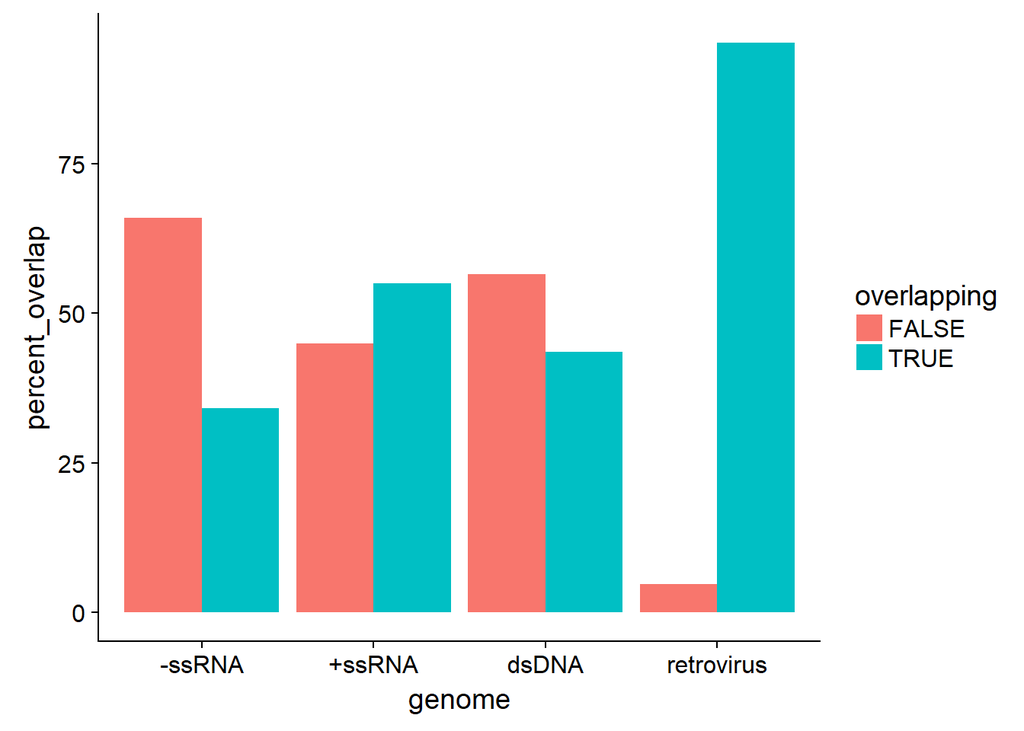

```r
genome_totals <- virus_tidy %>%
                 mutate(overlapping = ifelse(grepl("NA", virus_tidy$overlap, fixed = TRUE), "FALSE", "TRUE")) %>%
                 group_by(genome) %>%
                 summarise(total = n()) %>%
                 rbind(.,.) %>%
                 arrange(genome)

virus_tidy %>% mutate(overlapping = ifelse(grepl("NA", virus_tidy$overlap, fixed = TRUE), "FALSE", "TRUE")) %>%
               group_by(genome, overlapping) %>%
               summarise(ifoverlapping = n()) %>%
               left_join(.,genome_totals) %>%
               mutate(percent_overlap = ifoverlapping/total*100) %>%
               ggplot(aes(genome, percent_overlap, fill = overlapping)) +
                      geom_bar(stat = "identity", position = "dodge")
```

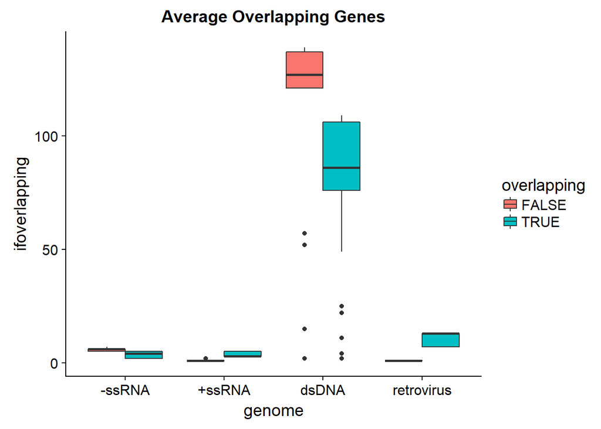

```r
virus_tidy %>% mutate(overlapping = ifelse(grepl("NA", virus_tidy$overlap, fixed = TRUE), "FALSE", "TRUE")) %>%
               group_by(virus, overlapping) %>%
               mutate(ifoverlapping = n()) %>%
               ggplot(aes(genome, ifoverlapping, fill = overlapping)) +
                      geom_boxplot() +
                      labs(xlab = "Genome Type",
                           ylab = "Average Number of Overlapping Genes",
                           title = "Average Overlapping Genes")
```

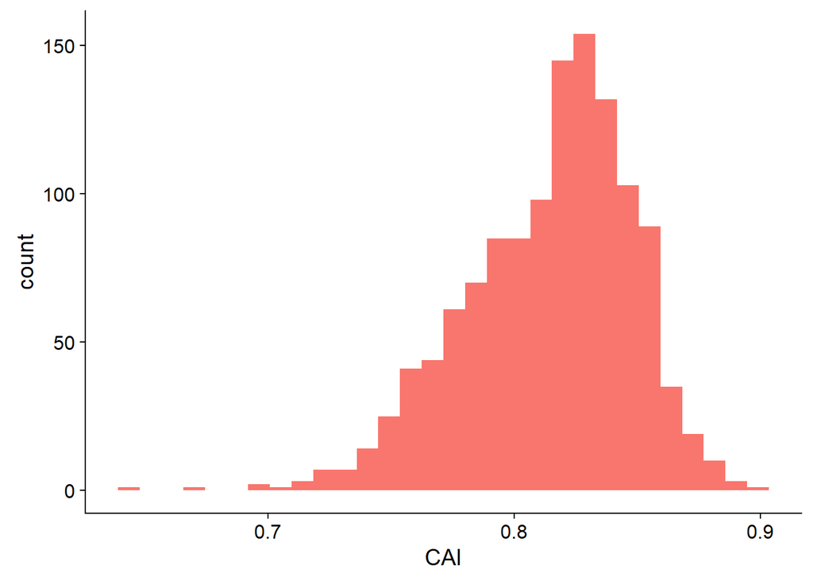

```r
virus_tidy %>% ggplot(aes(CAI, fill = "red")) +
                      geom_histogram() +
                      guides(fill = FALSE)
```

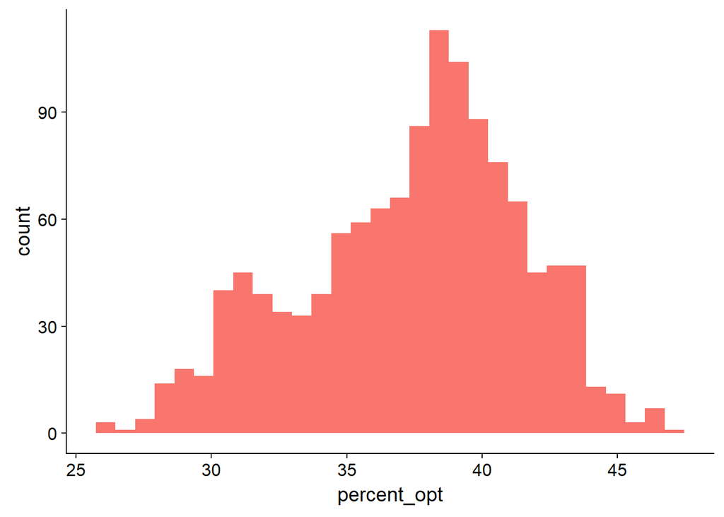

```r
virus_tidy %>% ggplot(aes(percent_opt, fill = "red")) +
                      geom_histogram() +
                      guides(fill = FALSE)
```

## linear model functions

These functions help plot linear model statistics on top of ggplots. They can even be faceted.

```r
lm_eqn <- function(x, y){
    m <- lm(y ~ x);
    f <- summary(m)$fstatistic;

    eq1 <- substitute(~~italic(r)^2~"="~r2*",",
         list(a = format(coef(m)[1], digits = 2),
              b = format(coef(m)[2], digits = 2),
             r2 = format(summary(m)$r.squared, digits = 3)));

    eq2 <- substitute(~~italic(p)~"="~pval,
         list(pval = as.character(format(pf(f[1], f[2], f[3], lower.tail = FALSE), digits = 3))));

   as.list(c(as.character(as.expression(eq1)), as.character(as.expression(eq2))));
   }

facet_lm_eqn <- function(data, group, x, y){
  i <- c(1:length(unique(group)))
  p <- lapply(i, function(i)

      p = as.double(unlist(data %>%
                           filter(group == sort(unique(group))[i]) %>%
                           select(x))))
  q <- lapply(i, function(i)
      q = as.double(unlist(data %>%
                           filter(group == sort(unique(group))[i]) %>%
                           select(y))))
  label <- unlist(lapply(i, function(i)
    lm_eqn(unlist(p[i]), unlist(q[i]))))
  names(label) <- sort(rep(unique(group), 2))
  unlist(label)
  }
```

### Confirming Known Relationships

In these plots we hoped to show an agreement between our two measurements of virus adaptiveness to human hosts, Codon Adaptability Index and Percent Optimal Codons. The agreement is highly significant which has previously been shown by other researchers.

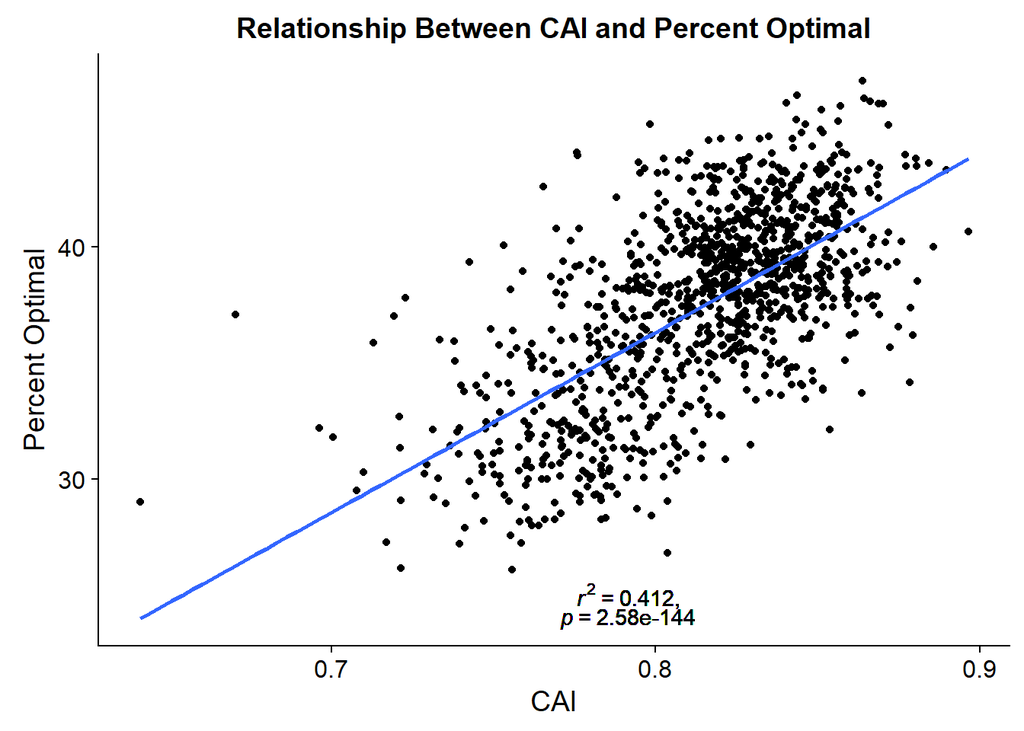

```r
virus_tidy %>% ggplot(aes(CAI, percent_opt)) +
      geom_point() +
      geom_smooth(method = lm, se = FALSE) +
      geom_text(aes(x = 0.79, y = 25),
                label = unlist(lm_eqn(virus_tidy$CAI, virus_tidy$percent_opt)[1]),
                parse = TRUE) +
      geom_text(aes(x = 0.79, y = 24),
                label = unlist(lm_eqn(virus_tidy$CAI, virus_tidy$percent_opt)[2]),
                parse = TRUE) +
      xlab("CAI") +
      ylab("Percent Optimal") +
      ggtitle("Relationship Between CAI and Percent Optimal")
```

These plots are intended to show consistency with the literature. It has previously been shown that as GC% increases, CAI decreases in a human model. Our data supports this trend suggesting our data is robust enough to draw conclusions from. Interestingly, -ssRNA viruses and unknown protein types show the opposite trend with GC and CAI but conform to the expected trend when percent optimal codons are considered.

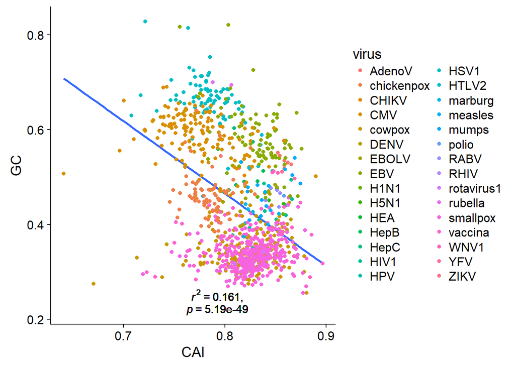

```r
virus_tidy %>% ggplot(aes(CAI, GC)) +
  geom_smooth(method = lm, se = FALSE) +
  geom_point(aes(col = virus)) +
  geom_text(aes(x = 0.79, y = 0.25),
            label = unlist(lm_eqn(virus_tidy$CAI, virus_tidy$GC)[1]),
            parse = TRUE) +
  geom_text(aes(x = 0.79, y = 0.22),
            label = unlist(lm_eqn(virus_tidy$CAI, virus_tidy$GC)[2]),
            parse = TRUE)
```

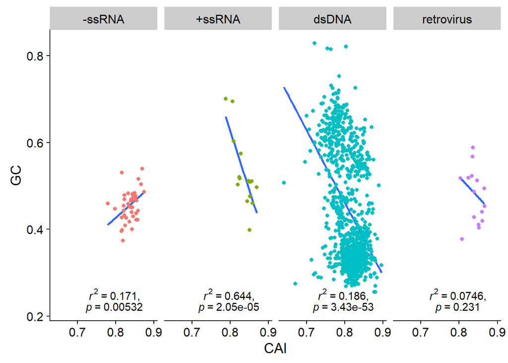

```r
label <- facet_lm_eqn(virus_tidy, virus_tidy$genome, "CAI", "GC")
virus_tidy %>% ggplot(aes(CAI, GC)) +
  geom_smooth(method = lm, se = FALSE) +
  geom_point(aes(col = genome)) +
  guides(col = FALSE) +
  facet_grid(.~genome) +
  geom_text(aes(x, y, label = R2),
            parse = TRUE,
            data = data.frame(x = 0.79,
                              y = 0.25,
                              R2 = unlist(label)[seq(1, length(label), 2)],
                              genome = names(label[seq(1, length(label), 2)]))) +
  geom_text(aes(x, y, label = pval),
            parse = TRUE,
            data = data.frame(x = 0.79,
                              y = 0.22,
                              pval = unlist(label)[seq(2, length(label), 2)],
                              genome = names(label[seq(2, length(label), 2)])))
```

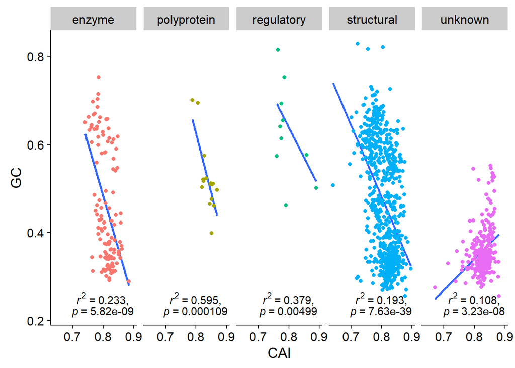

```r
label <- facet_lm_eqn(virus_tidy, virus_tidy$protein_type, "CAI", "GC")
virus_tidy %>% ggplot(aes(CAI, GC)) +
  geom_smooth(method = lm, se = FALSE) +
  geom_point(aes(col = protein_type)) +
  guides(col = FALSE) +
  facet_grid(.~protein_type) +
  geom_text(aes(x, y, label = R2),
            parse = TRUE,
            data = data.frame(x = 0.79,
                              y = 0.25,
                              R2 = unlist(label)[seq(1, length(label), 2)],
                              protein_type = names(label[seq(1, length(label), 2)]))) +
  geom_text(aes(x, y, label = pval),
            parse = TRUE,
            data = data.frame(x = 0.79,
                              y = 0.22,
                              pval = unlist(label)[seq(2, length(label), 2)],
                              protein_type = names(label[seq(2, length(label), 2)])))
```

This trend also stands when CAI is replaced with percent optimal codons.

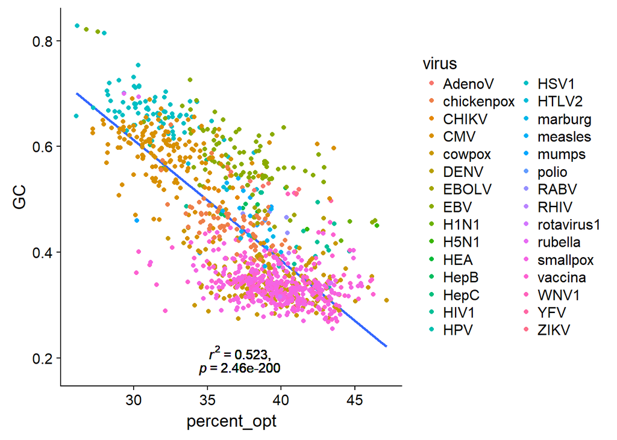

```r
virus_tidy %>% ggplot(aes(percent_opt, GC)) +
  geom_smooth(method = lm, se = FALSE) +
  geom_point(aes(col = virus)) +
  geom_text(aes(x = 37, y = 0.21),
            label = unlist(lm_eqn(virus_tidy$percent_opt, virus_tidy$GC)[1]),
            parse = TRUE) +
  geom_text(aes(x = 37, y = 0.18),
            label = unlist(lm_eqn(virus_tidy$percent_opt, virus_tidy$GC)[2]),
            parse = TRUE)
```

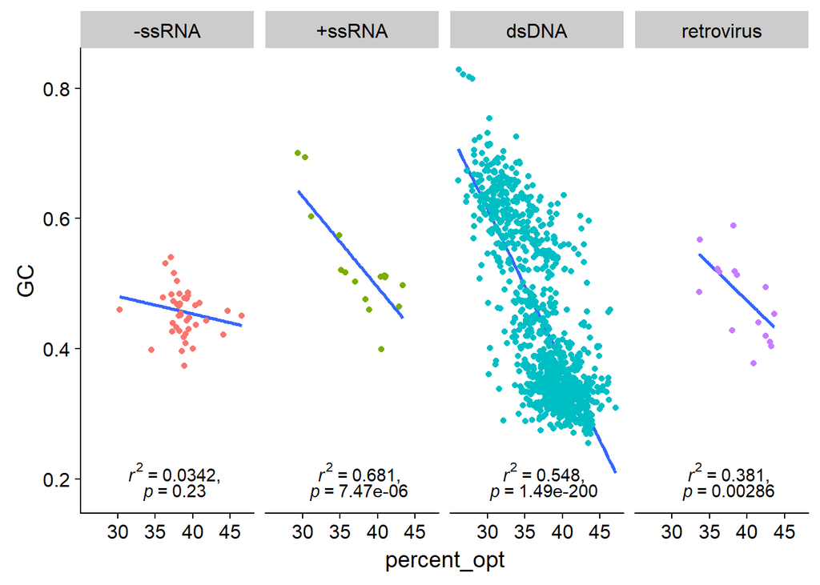

```r
label <- facet_lm_eqn(virus_tidy, virus_tidy$genome, "percent_opt", "GC")
virus_tidy %>% ggplot(aes(percent_opt, GC)) +
  geom_smooth(method = lm, se = FALSE) +
  geom_point(aes(col = genome)) +
  guides(col = FALSE) +
  facet_grid(.~genome) +
  geom_text(aes(x, y, label = R2),
            parse = TRUE,
            data = data.frame(x = 37,
                              y = 0.21,
                              R2 = unlist(label)[seq(1, length(label), 2)],
                              genome = names(label[seq(1, length(label), 2)]))) +
  geom_text(aes(x, y, label = pval),
            parse = TRUE,
            data = data.frame(x = 37,
                              y = 0.18,
                              pval = unlist(label)[seq(2, length(label), 2)],
                              genome = names(label[seq(2, length(label), 2)])))
```

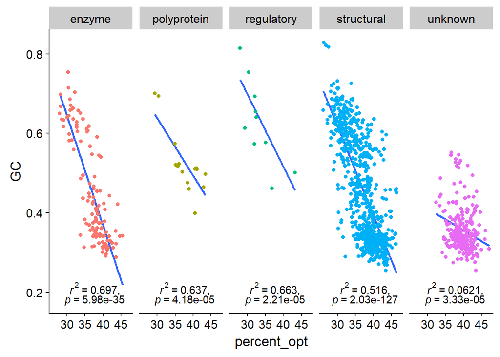

```r
label <- facet_lm_eqn(virus_tidy, virus_tidy$protein_type, "percent_opt", "GC")
virus_tidy %>% ggplot(aes(percent_opt, GC)) +
  geom_smooth(method = lm, se = FALSE) +
  geom_point(aes(col = protein_type)) +
  guides(col = FALSE) +
  facet_grid(.~protein_type) +
  geom_text(aes(x, y, label = R2),
            parse = TRUE,
            data = data.frame(x = 37,
                              y = 0.21,
                              R2 = unlist(label)[seq(1, length(label), 2)],
                              protein_type = names(label[seq(1, length(label), 2)]))) +
  geom_text(aes(x, y, label = pval),
            parse = TRUE,
            data = data.frame(x = 37,
                              y = 0.18,
                              pval = unlist(label)[seq(2, length(label), 2)],
                              protein_type = names(label[seq(2, length(label), 2)])))
```

### Testing our Hypotheses

An initial question is if any trends arise in codon adaptability based on genome type.

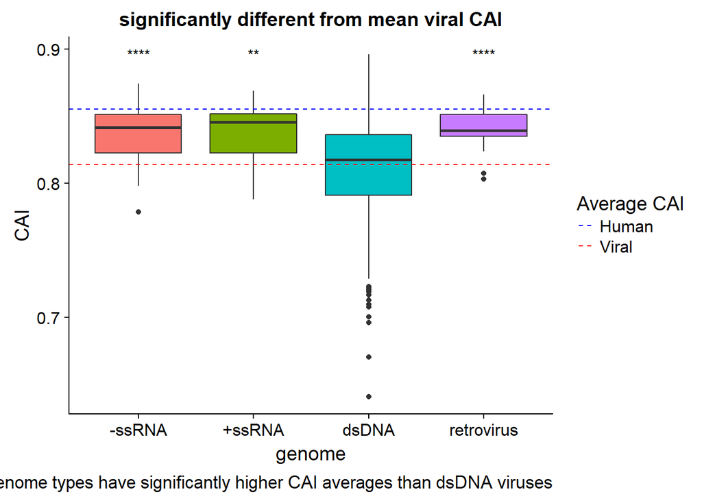

```r
virus_tidy %>% ggplot(aes(genome, CAI, fill = genome)) +
                     geom_boxplot() +
                     guides(fill = FALSE) +
                     geom_hline(aes(yintercept = mean(virus_tidy$CAI),
                                    linetype = "Viral"),
                                    color = "red") +
                     geom_hline(aes(yintercept = human_CAI,
                                    linetype = "Human"),
                                    color = "blue") +
                     scale_linetype_manual(name = "Average CAI",
                                           values = c(2, 2),
                                           guide = guide_legend(override.aes = list(color = c("blue", "red")))) +
                     stat_compare_means(label = "p.signif",
                                        method = "wilcox.test",
                                        ref.group = ".all.",
                                        hide.ns = TRUE) +
                     labs(xlab = "Genome Type",
                          title = "significantly different from mean viral CAI",
                          caption = "All other genome types have significantly higher CAI averages than dsDNA viruses")
```

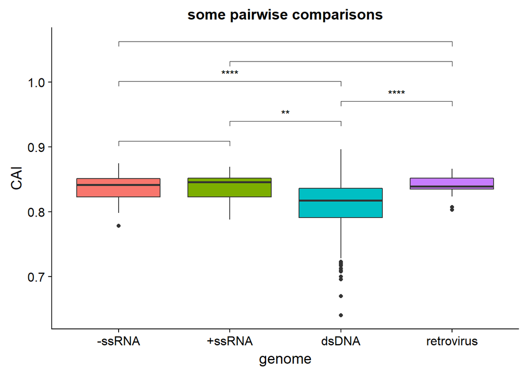

```r
my_comparisons <- list(c("-ssRNA", "+ssRNA"),
                       c("+ssRNA", "dsDNA"),
                       c("dsDNA", "retrovirus"),
                       c("-ssRNA", "dsDNA"),
                       c("+ssRNA", "retrovirus"),
                       c("-ssRNA", "retrovirus"))

virus_tidy %>% ggplot(aes(genome, CAI, fill = genome)) +
                      geom_boxplot() +
                      guides(fill = FALSE) +
                      stat_compare_means(comparisons = my_comparisons,
                                         method = "wilcox.test",
                                         label = "p.signif",
                                         hide.ns = TRUE) +
                      labs(title = "some pairwise comparisons",
                           xlab = "Genome Type")
```